# Phase_2_Overfit_Entire_Dataset

**Jesse Gempel**

**CMP SCI 4300-001**

**Professor Badri Adhikari**

**11/19/2024**

The **diabetes_binary_5050split_health_indicators_BRFSS2015.csv** dataset is suited for a binary classification problem to determine whether a person is:

1. Diabetic or prediabetic (classified as **1**)
2. Non-diabetic (classified as **0**)

This dataset is derived from the "Diabetes Health Indicators Dataset" page on the the Kaggle website. To view the dataset, please visit https://www.kaggle.com/datasets/alexteboul/diabetes-health-indicators-dataset.

**Import all necessary libraries before starting**

```python
import pandas as pd
import numpy as np
import matplotlib.pyplot as plt
import seaborn as sns
from tensorflow.keras.models import Sequential
from tensorflow.keras.layers import Dense
import random
```

# Phase 1: Data Analysis and Preparation

## 1.) Load dataset

```python
from google.colab import files
x = files.upload()
```

```python
dataset = pd.read_csv('diabetes_binary_5050split_health_indicators_BRFSS2015.csv', delimiter=",")
```

## 2.) Examine the dataset shape, rows, and columns

```python
print(dataset.shape)
```

```
(70692, 22)
```

The **diabetes_binary_5050split_health_indicators_BRFSS2015.csv** dataset contains **70,692** instances (rows) and **22** features (columns)---21 of which are considered predictors. These features are:

[output not shown]

[output not shown]

These descriptions were summarized from Kaggle. The link to access fuller descriptions is https://www.kaggle.com/code/alexteboul/diabetes-health-indicators-dataset-notebook.

```python
dataset.head()
```

|  | Diabetes_binary | HighBP | HighChol | CholCheck | BMI | Smoker | Stroke | HeartDiseaseorAttack | PhysActivity | Fruits | ... | AnyHealthcare | NoDocbcCost | GenHlth | MentHlth | PhysHlth | DiffWalk | Sex | Age | Education | Income |
| --- | --- | --- | --- | --- | --- | --- | --- | --- | --- | --- | --- | --- | --- | --- | --- | --- | --- | --- | --- | --- | --- |
| 0 | 0.0 | 1.0 | 0.0 | 1.0 | 26.0 | 0.0 | 0.0 | 0.0 | 1.0 | 0.0 | ... | 1.0 | 0.0 | 3.0 | 5.0 | 30.0 | 0.0 | 1.0 | 4.0 | 6.0 | 8.0 |
| 1 | 0.0 | 1.0 | 1.0 | 1.0 | 26.0 | 1.0 | 1.0 | 0.0 | 0.0 | 1.0 | ... | 1.0 | 0.0 | 3.0 | 0.0 | 0.0 | 0.0 | 1.0 | 12.0 | 6.0 | 8.0 |
| 2 | 0.0 | 0.0 | 0.0 | 1.0 | 26.0 | 0.0 | 0.0 | 0.0 | 1.0 | 1.0 | ... | 1.0 | 0.0 | 1.0 | 0.0 | 10.0 | 0.0 | 1.0 | 13.0 | 6.0 | 8.0 |
| 3 | 0.0 | 1.0 | 1.0 | 1.0 | 28.0 | 1.0 | 0.0 | 0.0 | 1.0 | 1.0 | ... | 1.0 | 0.0 | 3.0 | 0.0 | 3.0 | 0.0 | 1.0 | 11.0 | 6.0 | 8.0 |
| 4 | 0.0 | 0.0 | 0.0 | 1.0 | 29.0 | 1.0 | 0.0 | 0.0 | 1.0 | 1.0 | ... | 1.0 | 0.0 | 2.0 | 0.0 | 0.0 | 0.0 | 0.0 | 8.0 | 5.0 | 8.0 |

5 rows × 22 columns

```python
dataset.tail()
```

|  | Diabetes_binary | HighBP | HighChol | CholCheck | BMI | Smoker | Stroke | HeartDiseaseorAttack | PhysActivity | Fruits | ... | AnyHealthcare | NoDocbcCost | GenHlth | MentHlth | PhysHlth | DiffWalk | Sex | Age | Education | Income |
| --- | --- | --- | --- | --- | --- | --- | --- | --- | --- | --- | --- | --- | --- | --- | --- | --- | --- | --- | --- | --- | --- |
| 70687 | 1.0 | 0.0 | 1.0 | 1.0 | 37.0 | 0.0 | 0.0 | 0.0 | 0.0 | 0.0 | ... | 1.0 | 0.0 | 4.0 | 0.0 | 0.0 | 0.0 | 0.0 | 6.0 | 4.0 | 1.0 |
| 70688 | 1.0 | 0.0 | 1.0 | 1.0 | 29.0 | 1.0 | 0.0 | 1.0 | 0.0 | 1.0 | ... | 1.0 | 0.0 | 2.0 | 0.0 | 0.0 | 1.0 | 1.0 | 10.0 | 3.0 | 6.0 |
| 70689 | 1.0 | 1.0 | 1.0 | 1.0 | 25.0 | 0.0 | 0.0 | 1.0 | 0.0 | 1.0 | ... | 1.0 | 0.0 | 5.0 | 15.0 | 0.0 | 1.0 | 0.0 | 13.0 | 6.0 | 4.0 |
| 70690 | 1.0 | 1.0 | 1.0 | 1.0 | 18.0 | 0.0 | 0.0 | 0.0 | 0.0 | 0.0 | ... | 1.0 | 0.0 | 4.0 | 0.0 | 0.0 | 1.0 | 0.0 | 11.0 | 2.0 | 4.0 |
| 70691 | 1.0 | 1.0 | 1.0 | 1.0 | 25.0 | 0.0 | 0.0 | 1.0 | 1.0 | 1.0 | ... | 1.0 | 0.0 | 2.0 | 0.0 | 0.0 | 0.0 | 0.0 | 9.0 | 6.0 | 2.0 |

5 rows × 22 columns

```python
# .iloc is used to ensure that ALL attribute's values can be seen, unlike the two tables above where they are cut off.

row_number = random.randint(0, len(dataset))
print(f"Attribute information for Row {row_number} out of {len(dataset)} \n\n{dataset.iloc[row_number]}")
```

```
Attribute information for Row 18145 out of 70692

Diabetes_binary          0.0
HighBP                   0.0
HighChol                 0.0
CholCheck                1.0
BMI                     27.0
Smoker                   0.0
Stroke                   0.0
HeartDiseaseorAttack     0.0
PhysActivity             1.0
Fruits                   1.0
Veggies                  1.0
HvyAlcoholConsump        0.0
AnyHealthcare            1.0
NoDocbcCost              0.0
GenHlth                  2.0
MentHlth                 0.0
PhysHlth                 0.0
DiffWalk                 0.0
Sex                      0.0
Age                     12.0
Education                5.0
Income                   3.0
Name: 18145, dtype: float64
```

## 3.) Find any missing data

```python
dataset.isnull().sum()
```

|  | 0 |
| --- | --- |
| Diabetes_binary | 0 |
| HighBP | 0 |
| HighChol | 0 |
| CholCheck | 0 |
| BMI | 0 |
| Smoker | 0 |
| Stroke | 0 |
| HeartDiseaseorAttack | 0 |
| PhysActivity | 0 |
| Fruits | 0 |
| Veggies | 0 |
| HvyAlcoholConsump | 0 |
| AnyHealthcare | 0 |
| NoDocbcCost | 0 |
| GenHlth | 0 |
| MentHlth | 0 |
| PhysHlth | 0 |
| DiffWalk | 0 |
| Sex | 0 |
| Age | 0 |
| Education | 0 |
| Income | 0 |

**dtype:** int64

Because every value in the table above contains a 0, it is apparent that no missing data exists in the dataset.

## 4.) Clean up attribute titles

```python
dataset.columns = ('Diabetes (binary target)',
                   'High Blood Pressure (y/n)',
                   'High Cholesterol (y/n)',
                   'Cholesterol Checked (y/n)',
                   'BMI',
                   'Smoke (y/n)',
                   'Stroke (y/n)',
                   'Heart Attack (y/n)',
                   'Exercise (y/n)',
                   'Fruits (y/n)',
                   'Veggies (y/n)',
                   'Heavy Alcohol Consumption (y/n)',
                   'Health Coverage (y/n)',
                   'Cost Prevents Doctor Visit (y/n)',
                   'General Health (1-5)',
                   'Days Poor Mental Health',
                   'Days Poor Physical Health',
                   'Stairs Difficulty (y/n)',
                   'Sex (M/F)',
                   'Age',
                   'Education',
                   'Income')

# Converts column names to list to make specifying columns for describe() method easier.
column_list = dataset.columns.tolist()
```

## 5.) Visualize distribution of the two classes (output labels)

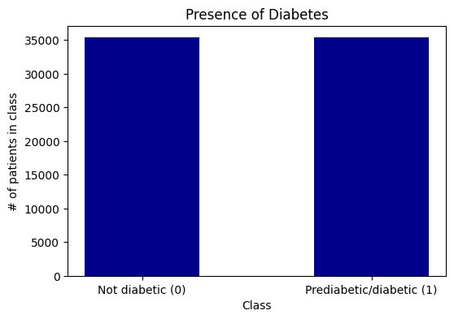

```python
class_distribution = dataset["Diabetes (binary target)"].value_counts().to_dict()
classes = list(class_distribution.keys())
number_of_patients_in_class = list(class_distribution.values())

fig = plt.figure(figsize = (6, 4))

plt.bar(classes, number_of_patients_in_class, color="darkblue", width=0.5)

plt.xlabel("Class")
plt.xticks([0, 1], ["Not diabetic (0)", "Prediabetic/diabetic (1)"])
plt.ylabel("# of patients in class")
plt.title("Presence of Diabetes")

plt.show()
```

```python
diabetic_count = number_of_patients_in_class[1]
non_diabetic_count = number_of_patients_in_class[0]

diabetic_percentage = (diabetic_count / (diabetic_count + non_diabetic_count)) * 100
non_diabetic_percentage = (non_diabetic_count / (diabetic_count + non_diabetic_count)) * 100

print("Class:\t\tDescription:\t\t\t\t\tPatient count:\t\tPercentage:")
print(f"{classes[0]}\t\tNumber of non-diabetic patients\t\t\t{non_diabetic_count}\t\t\t{non_diabetic_percentage}%")
print(f"{classes[1]}\t\tNumber of pre-diabetic/diabetic patients\t{diabetic_count}\t\t\t{diabetic_percentage}%")
```

```
Class:		Description:					Patient count:		Percentage:
0.0		Number of non-diabetic patients			35346			50.0%
1.0		Number of pre-diabetic/diabetic patients	35346			50.0%
```

Upon observing the distribution of the two classes above, it turns out that the data is *equally distributed*. Both classes appear to have exactly **35,346** rows, plus the distribution percentages are exactly **50.0%**. Therefore, it is safe to say that the data is not heavily imbalanced (or even remotely imbalanced at all). We can continue utilizing the dataset to solve this binary classification problem.

## 6.) Visualize distribution of all predictors with histogram (input labels)

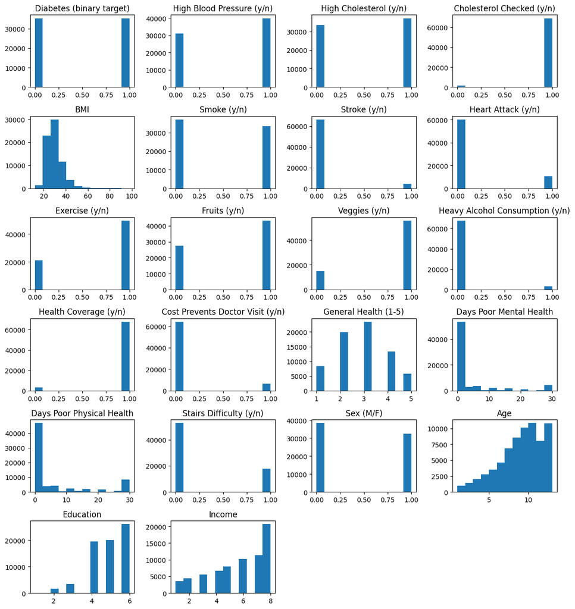

```python
%matplotlib inline

histogram = dataset.hist(figsize=(12, 13), layout=(6, 4), bins=12, grid=False)

plt.tight_layout()
plt.show()
```

## 7.) Illustrate range of values for predictors

#### **7.1: Range of values for predictors 1 through 7**

```python
dataset[column_list[1:8]].describe()
```

|  | High Blood Pressure (y/n) | High Cholesterol (y/n) | Cholesterol Checked (y/n) | BMI | Smoke (y/n) | Stroke (y/n) | Heart Attack (y/n) |
| --- | --- | --- | --- | --- | --- | --- | --- |
| count | 70692.000000 | 70692.000000 | 70692.000000 | 70692.000000 | 70692.000000 | 70692.000000 | 70692.000000 |
| mean | 0.563458 | 0.525703 | 0.975259 | 29.856985 | 0.475273 | 0.062171 | 0.147810 |
| std | 0.495960 | 0.499342 | 0.155336 | 7.113954 | 0.499392 | 0.241468 | 0.354914 |
| min | 0.000000 | 0.000000 | 0.000000 | 12.000000 | 0.000000 | 0.000000 | 0.000000 |
| 25% | 0.000000 | 0.000000 | 1.000000 | 25.000000 | 0.000000 | 0.000000 | 0.000000 |
| 50% | 1.000000 | 1.000000 | 1.000000 | 29.000000 | 0.000000 | 0.000000 | 0.000000 |
| 75% | 1.000000 | 1.000000 | 1.000000 | 33.000000 | 1.000000 | 0.000000 | 0.000000 |
| max | 1.000000 | 1.000000 | 1.000000 | 98.000000 | 1.000000 | 1.000000 | 1.000000 |

For the first seven columns of the dataset, every predictor above (except BMI) appears to have a range between 0 and 1. This scenerio occurs because those attributes only hold binary values (0 or 1). When the data was gathered, each patient was asked yes/no questions about their blood pressure, cholesterol, checking of cholesterol, smoking habits, stroke history, and heart attack history.

#### **7.2: Range of values for predictors 8 through 13**

```python
dataset[column_list[8:14]].describe()
```

|  | Exercise (y/n) | Fruits (y/n) | Veggies (y/n) | Heavy Alcohol Consumption (y/n) | Health Coverage (y/n) | Cost Prevents Doctor Visit (y/n) |
| --- | --- | --- | --- | --- | --- | --- |
| count | 70692.000000 | 70692.000000 | 70692.000000 | 70692.000000 | 70692.000000 | 70692.000000 |
| mean | 0.703036 | 0.611795 | 0.788774 | 0.042721 | 0.954960 | 0.093914 |
| std | 0.456924 | 0.487345 | 0.408181 | 0.202228 | 0.207394 | 0.291712 |
| min | 0.000000 | 0.000000 | 0.000000 | 0.000000 | 0.000000 | 0.000000 |
| 25% | 0.000000 | 0.000000 | 1.000000 | 0.000000 | 1.000000 | 0.000000 |
| 50% | 1.000000 | 1.000000 | 1.000000 | 0.000000 | 1.000000 | 0.000000 |
| 75% | 1.000000 | 1.000000 | 1.000000 | 0.000000 | 1.000000 | 0.000000 |
| max | 1.000000 | 1.000000 | 1.000000 | 1.000000 | 1.000000 | 1.000000 |

In the table above, patients were asked yes/no questions about their exercise habits, fruit/vegetable intake, alcohol intake, health coverage, and their ability to attend doctor's visits due to cost. For this reason, all the quartile values only contain integer values 0 or 1.

```python
dataset[column_list[14:22]].describe()
```

|  | General Health (1-5) | Days Poor Mental Health | Days Poor Physical Health | Stairs Difficulty (y/n) | Sex (M/F) | Age | Education | Income |
| --- | --- | --- | --- | --- | --- | --- | --- | --- |
| count | 70692.000000 | 70692.000000 | 70692.000000 | 70692.000000 | 70692.000000 | 70692.000000 | 70692.000000 | 70692.000000 |
| mean | 2.837082 | 3.752037 | 5.810417 | 0.252730 | 0.456997 | 8.584055 | 4.920953 | 5.698311 |
| std | 1.113565 | 8.155627 | 10.062261 | 0.434581 | 0.498151 | 2.852153 | 1.029081 | 2.175196 |
| min | 1.000000 | 0.000000 | 0.000000 | 0.000000 | 0.000000 | 1.000000 | 1.000000 | 1.000000 |
| 25% | 2.000000 | 0.000000 | 0.000000 | 0.000000 | 0.000000 | 7.000000 | 4.000000 | 4.000000 |
| 50% | 3.000000 | 0.000000 | 0.000000 | 0.000000 | 0.000000 | 9.000000 | 5.000000 | 6.000000 |
| 75% | 4.000000 | 2.000000 | 6.000000 | 1.000000 | 1.000000 | 11.000000 | 6.000000 | 8.000000 |
| max | 5.000000 | 30.000000 | 30.000000 | 1.000000 | 1.000000 | 13.000000 | 6.000000 | 8.000000 |

Quartile values for **Stairs Difficulty** and **Sex (M/F)** are exclusively 0 or 1. This scenario occurs due to the nature of their data holding binary values. The data for the Stairs Difficulty feature was gathered through a yes/no question asked from the doctor to the patient. The Sex (M/F) assigns a 0 for female and a 1 for male.

The **General Health (1-5)** predictor holds data that serves as a rating from 1 to 5. Only 5 possible values exist for that predictor, so the quartiles appear to behave almost uniformly as the values increase.

The **Education** predictor categorizes values between 1 and 6. This method of categorization can be found on https://www.icpsr.umich.edu/web/NAHDAP/studies/34085/datasets/0001/variables/EDUCA?archive=NAHDAP. When comparing the lower quartile to the maximum value, the values range between 4 and 6. This observation dictates that around 75% of people in the study obtained at least a high school degree or GED.

This dataset also uses numbers to illustrate categories for the **Income** predictor. Values 1 through 8 represent an income bracket in which a patient belongs. This breakdown is demonstrated at https://www.icpsr.umich.edu/web/RCMD/studies/34085/datasets/0001/variables/INCOME2?archive=RCMD. The mean and median appear to be around 6, meaning that the average person in the study appears to make between $35,000 and $50,000/yr. It can also be said that at least 25% of patients make over $75,000/yr since the upper quartile (75%) equals the maximum value.

## 8.) Illustrate range of values for target variable Diabetes (binary target)

```python
dataset[column_list[0]].describe()
```

|  | Diabetes (binary target) |
| --- | --- |
| count | 70692.000000 |
| mean | 0.500000 |
| std | 0.500004 |
| min | 0.000000 |
| 25% | 0.000000 |
| 50% | 0.500000 |
| 75% | 1.000000 |
| max | 1.000000 |

**dtype:** float64

The target variable **Diabetes (binary target)** contains an *exactly* equal breakdown of 0's and 1's---0 for if a patient is ***not* diabetic**, and 1 if a patient is either **diabetic or prediabetic**. As a result, the minimum value equals the lower quartile (25%), the maximum value equals the upper quartile (75%), and the median equals the mean.

## 9.) Normalize the data

```python
mean = dataset.mean(axis=0)
stddev = dataset.std(axis=0)

norm_dataset = (dataset - mean) / stddev
```

## 10.) Visualize *normalized* distributions with histogram

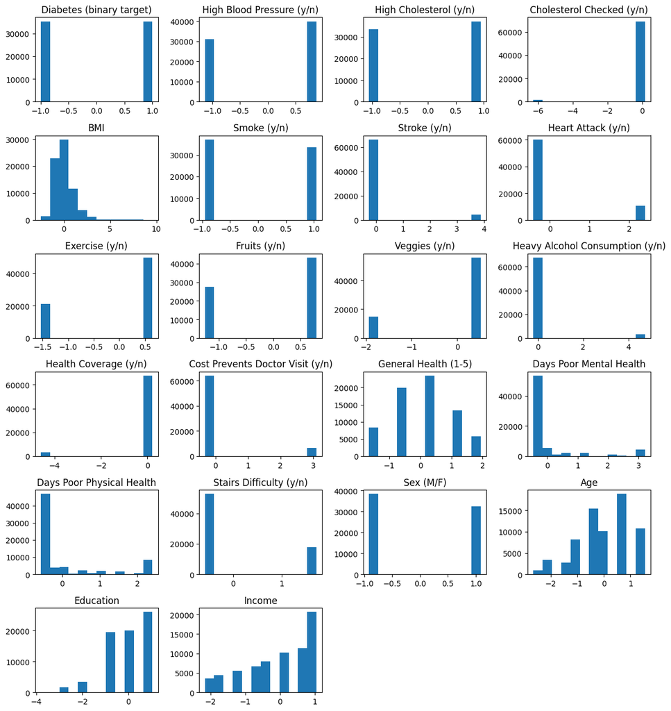

```python
%matplotlib inline

histogram = norm_dataset.hist(figsize=(12, 13), layout=(6, 4), bins=12, grid=False)

plt.tight_layout()
plt.show()
```

# Phase 2: Building a Model to Overfit the Dataset

## 1.) Select features and target variables

```python
X = norm_dataset.iloc[:, 1:]
Y = dataset.iloc[:, 0]                      # Use the original output values BEFORE normalization happened.
                                            # That way, the model can continue working with binary output values.
                                            # Output columns are somehow in the FIRST column with this dataset.
```

## 2.) Create an overfitting model

```python
overfitting_model = Sequential()

overfitting_model.add(Dense(512, activation='sigmoid', input_shape=(X.shape[1],)))
overfitting_model.add(Dense(256, activation='sigmoid'))
overfitting_model.add(Dense(64, activation='sigmoid'))
overfitting_model.add(Dense(32, activation='sigmoid'))
overfitting_model.add(Dense(16, activation='sigmoid'))


overfitting_model.add(Dense(1, activation='sigmoid'))
```

```python
overfitting_model.summary()
```

```
Model: "sequential"
```

```
┏━━━━━━━━━━━━━━━━━━━━━━━━━━━━━━━━━━━━━━┳━━━━━━━━━━━━━━━━━━━━━━━━━━━━━┳━━━━━━━━━━━━━━━━━┓
┃ Layer (type)                         ┃ Output Shape                ┃         Param # ┃
┡━━━━━━━━━━━━━━━━━━━━━━━━━━━━━━━━━━━━━━╇━━━━━━━━━━━━━━━━━━━━━━━━━━━━━╇━━━━━━━━━━━━━━━━━┩
│ dense (Dense)                        │ (None, 512)                 │          11,264 │
├──────────────────────────────────────┼─────────────────────────────┼─────────────────┤
│ dense_1 (Dense)                      │ (None, 256)                 │         131,328 │
├──────────────────────────────────────┼─────────────────────────────┼─────────────────┤
│ dense_2 (Dense)                      │ (None, 64)                  │          16,448 │
├──────────────────────────────────────┼─────────────────────────────┼─────────────────┤
│ dense_3 (Dense)                      │ (None, 32)                  │           2,080 │
├──────────────────────────────────────┼─────────────────────────────┼─────────────────┤
│ dense_4 (Dense)                      │ (None, 16)                  │             528 │
├──────────────────────────────────────┼─────────────────────────────┼─────────────────┤
│ dense_5 (Dense)                      │ (None, 1)                   │              17 │
└──────────────────────────────────────┴─────────────────────────────┴─────────────────┘
```

```
 Total params: 484,997 (1.85 MB)
```

```
 Trainable params: 161,665 (631.50 KB)
```

```
 Non-trainable params: 0 (0.00 B)
```

```
 Optimizer params: 323,332 (1.23 MB)
```

## 3.) Compile the model

```python
overfitting_model.compile(loss='binary_crossentropy', optimizer = 'adam', metrics=['accuracy'])
```

## 4.) Run the model

```python
history = overfitting_model.fit(X, Y, epochs = 400, batch_size = 16)
```

```
4419/4419 ━━━━━━━━━━━━━━━━━━━━ 17s 2ms/step - accuracy: 0.7072 - loss: 0.5559
4419/4419 ━━━━━━━━━━━━━━━━━━━━ 15s 2ms/step - accuracy: 0.7479 - loss: 0.5116
4419/4419 ━━━━━━━━━━━━━━━━━━━━ 8s 2ms/step - accuracy: 0.7459 - loss: 0.5124
4419/4419 ━━━━━━━━━━━━━━━━━━━━ 9s 2ms/step - accuracy: 0.7519 - loss: 0.5071
4419/4419 ━━━━━━━━━━━━━━━━━━━━ 9s 2ms/step - accuracy: 0.7523 - loss: 0.5066
4419/4419 ━━━━━━━━━━━━━━━━━━━━ 8s 2ms/step - accuracy: 0.7493 - loss: 0.5073
4419/4419 ━━━━━━━━━━━━━━━━━━━━ 10s 2ms/step - accuracy: 0.7501 - loss: 0.5063
4419/4419 ━━━━━━━━━━━━━━━━━━━━ 9s 2ms/step - accuracy: 0.7505 - loss: 0.5058
4419/4419 ━━━━━━━━━━━━━━━━━━━━ 8s 2ms/step - accuracy: 0.7525 - loss: 0.5020
4419/4419 ━━━━━━━━━━━━━━━━━━━━ 10s 2ms/step - accuracy: 0.7513 - loss: 0.5054
4419/4419 ━━━━━━━━━━━━━━━━━━━━ 11s 2ms/step - accuracy: 0.7520 - loss: 0.5030
4419/4419 ━━━━━━━━━━━━━━━━━━━━ 11s 2ms/step - accuracy: 0.7515 - loss: 0.5033
4419/4419 ━━━━━━━━━━━━━━━━━━━━ 9s 2ms/step - accuracy: 0.7533 - loss: 0.5010
4419/4419 ━━━━━━━━━━━━━━━━━━━━ 8s 2ms/step - accuracy: 0.7528 - loss: 0.5034
4419/4419 ━━━━━━━━━━━━━━━━━━━━ 10s 2ms/step - accuracy: 0.7525 - loss: 0.5028
4419/4419 ━━━━━━━━━━━━━━━━━━━━ 11s 2ms/step - accuracy: 0.7530 - loss: 0.5009
4419/4419 ━━━━━━━━━━━━━━━━━━━━ 9s 2ms/step - accuracy: 0.7524 - loss: 0.5016
4419/4419 ━━━━━━━━━━━━━━━━━━━━ 8s 2ms/step - accuracy: 0.7557 - loss: 0.4963
4419/4419 ━━━━━━━━━━━━━━━━━━━━ 10s 2ms/step - accuracy: 0.7512 - loss: 0.5030
4419/4419 ━━━━━━━━━━━━━━━━━━━━ 11s 2ms/step - accuracy: 0.7537 - loss: 0.4991
4419/4419 ━━━━━━━━━━━━━━━━━━━━ 11s 2ms/step - accuracy: 0.7573 - loss: 0.4960
4419/4419 ━━━━━━━━━━━━━━━━━━━━ 10s 2ms/step - accuracy: 0.7546 - loss: 0.4986
4419/4419 ━━━━━━━━━━━━━━━━━━━━ 10s 2ms/step - accuracy: 0.7555 - loss: 0.4980
4419/4419 ━━━━━━━━━━━━━━━━━━━━ 10s 2ms/step - accuracy: 0.7531 - loss: 0.4961
4419/4419 ━━━━━━━━━━━━━━━━━━━━ 9s 2ms/step - accuracy: 0.7581 - loss: 0.4961
4419/4419 ━━━━━━━━━━━━━━━━━━━━ 9s 2ms/step - accuracy: 0.7560 - loss: 0.4980
4419/4419 ━━━━━━━━━━━━━━━━━━━━ 13s 3ms/step - accuracy: 0.7536 - loss: 0.4972
4419/4419 ━━━━━━━━━━━━━━━━━━━━ 17s 2ms/step - accuracy: 0.7588 - loss: 0.4932
4419/4419 ━━━━━━━━━━━━━━━━━━━━ 10s 2ms/step - accuracy: 0.7578 - loss: 0.4932
4419/4419 ━━━━━━━━━━━━━━━━━━━━ 10s 2ms/step - accuracy: 0.7576 - loss: 0.4943
4419/4419 ━━━━━━━━━━━━━━━━━━━━ 8s 2ms/step - accuracy: 0.7586 - loss: 0.4912
4419/4419 ━━━━━━━━━━━━━━━━━━━━ 11s 2ms/step - accuracy: 0.7595 - loss: 0.4912
4419/4419 ━━━━━━━━━━━━━━━━━━━━ 9s 2ms/step - accuracy: 0.7607 - loss: 0.4898
4419/4419 ━━━━━━━━━━━━━━━━━━━━ 10s 2ms/step - accuracy: 0.7589 - loss: 0.4915
4419/4419 ━━━━━━━━━━━━━━━━━━━━ 8s 2ms/step - accuracy: 0.7573 - loss: 0.4915
4419/4419 ━━━━━━━━━━━━━━━━━━━━ 11s 2ms/step - accuracy: 0.7623 - loss: 0.4873
4419/4419 ━━━━━━━━━━━━━━━━━━━━ 9s 2ms/step - accuracy: 0.7626 - loss: 0.4862
4419/4419 ━━━━━━━━━━━━━━━━━━━━ 10s 2ms/step - accuracy: 0.7659 - loss: 0.4838
4419/4419 ━━━━━━━━━━━━━━━━━━━━ 8s 2ms/step - accuracy: 0.7621 - loss: 0.4854
4419/4419 ━━━━━━━━━━━━━━━━━━━━ 9s 2ms/step - accuracy: 0.7633 - loss: 0.4843
```

[output cut: 345 more lines]

```
4419/4419 ━━━━━━━━━━━━━━━━━━━━ 10s 2ms/step - accuracy: 0.9788 - loss: 0.0515
4419/4419 ━━━━━━━━━━━━━━━━━━━━ 10s 2ms/step - accuracy: 0.9800 - loss: 0.0513
4419/4419 ━━━━━━━━━━━━━━━━━━━━ 9s 2ms/step - accuracy: 0.9799 - loss: 0.0501
4419/4419 ━━━━━━━━━━━━━━━━━━━━ 9s 2ms/step - accuracy: 0.9807 - loss: 0.0501
4419/4419 ━━━━━━━━━━━━━━━━━━━━ 10s 2ms/step - accuracy: 0.9811 - loss: 0.0500
4419/4419 ━━━━━━━━━━━━━━━━━━━━ 10s 2ms/step - accuracy: 0.9802 - loss: 0.0505
4419/4419 ━━━━━━━━━━━━━━━━━━━━ 8s 2ms/step - accuracy: 0.9811 - loss: 0.0486
4419/4419 ━━━━━━━━━━━━━━━━━━━━ 11s 2ms/step - accuracy: 0.9807 - loss: 0.0491
4419/4419 ━━━━━━━━━━━━━━━━━━━━ 10s 2ms/step - accuracy: 0.9797 - loss: 0.0501
4419/4419 ━━━━━━━━━━━━━━━━━━━━ 10s 2ms/step - accuracy: 0.9806 - loss: 0.0469
4419/4419 ━━━━━━━━━━━━━━━━━━━━ 10s 2ms/step - accuracy: 0.9812 - loss: 0.0504
4419/4419 ━━━━━━━━━━━━━━━━━━━━ 10s 2ms/step - accuracy: 0.9813 - loss: 0.0481
4419/4419 ━━━━━━━━━━━━━━━━━━━━ 9s 2ms/step - accuracy: 0.9802 - loss: 0.0506
4419/4419 ━━━━━━━━━━━━━━━━━━━━ 8s 2ms/step - accuracy: 0.9819 - loss: 0.0458
4419/4419 ━━━━━━━━━━━━━━━━━━━━ 10s 2ms/step - accuracy: 0.9810 - loss: 0.0491
```

## 5.) Visualize the model's results

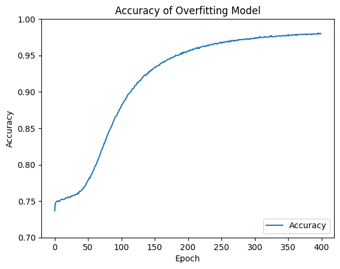

```python
plt.plot(history.history['accuracy'], label='Accuracy')
plt.title("Accuracy of Overfitting Model")

plt.xlabel('Epoch')
plt.ylabel('Accuracy')
plt.ylim([0.7, 1])
plt.legend(loc='lower right')
```